# Statistics_for_Data_Science_Practice

## **Importing the necessary libraries**

```python
# Library used for data manipulation and analysis
import pandas as pd

# Library used for working with arrays
import numpy as np

# Libraries for visualization
import matplotlib.pyplot as plt
%matplotlib inline

import seaborn as sns

# This library contains a large number of probability distributions as well as a growing library of statistical functions
import scipy.stats as stats
```

## **Binomial Distribution**

### **Q1. A LED bulb manufacturing company regularly conducts quality checks at specified periods on the products it manufactures. Historically, the failure rate for LED light bulbs, that the company manufactures is 5%. Suppose a random sample of 10 LED light bulbs is selected. Find the probability distribution for the defective bulbs and answer the following questions.**

```python
# Failure rate for LED light bulbs is 5%
p = 0.05

# Take a sample size
n = 10

# Create array of different possible number of defective light bulbs
k = np.arange(0, 11)

# Grab binomial distribution and print
binomial = stats.binom.pmf(k, n, p)
print(binomial)
```

```
[5.98736939e-01 3.15124705e-01 7.46347985e-02 1.04750594e-02
 9.64808106e-04 6.09352488e-05 2.67259863e-06 8.03789062e-08
 1.58642578e-09 1.85546875e-11 9.76562500e-14]
```

**Plot Binomial Distribution**

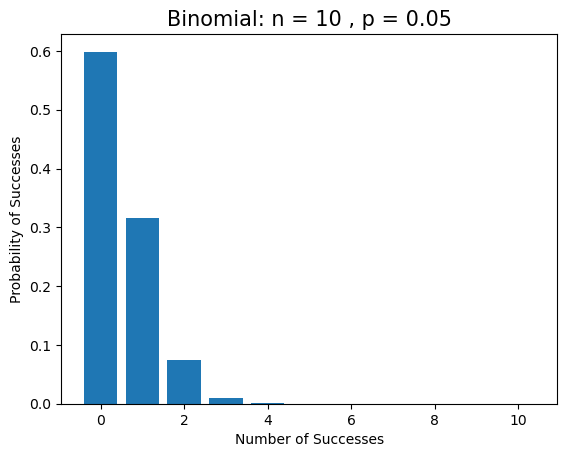

```python
plt.bar(k, binomial)

plt.title('Binomial: n = %i , p = %.2f' % (n, p), fontsize = 15)

plt.xlabel('Number of Successes')

plt.ylabel('Probability of Successes')

plt.show()
```

**a) What is the probability that none of the LED bulbs are defective?**

```python
print('%1.4f' % binomial[0])
```

```
0.5987
```

**b) What is the probability that exactly one LED bulb is defective?**

```python
print('%1.4f' % binomial[1])
```

```
0.3151
```

**c) What is the probability that two or fewer LED bulbs are defective?**

**Hint:** We need to calculate the cumulative probability of two or fewer LED bulbs being defective.

```python
# Calculate cumulative probability
cumulative_binomial = stats.binom.cdf(k, n, p)

# Print results
print('%1.4f' % cumulative_binomial[2])
```

```
0.9885
```

**d) What is the probability that three or more LED bulbs are defective?**

**Hint:** We need to subtract the cumulative probability of up to 2 defective LED bulbs from 1.

```python
# Calculate probability of 2 defective light bulbs
P = 1 - cumulative_binomial[2]

# Print results
print('%1.4f' % P)
```

```
0.0115
```

### **Q2. During an NBA game, a basketball player has two foul shots (free throw) and the conversion rate of foul shots is 93%. Find the following probabilities.**

```python
# Set the conversion rate of foul shots to decimal
conversionRate = 0.93
```

**a) What is the probability that the player will convert both the shots?**

```python
print(round(stats.binom.pmf(2, 2, 0.93), 4))
```

```
0.8649
```

**b) What is the probability that the player will convert at least one shot?**

```python
print(round((1 - stats.binom.cdf(0, 2, 0.93)), 4))
```

```
0.9951
```

### **Q3. Over a long period in a large multinomial corporation, 10% of all sales trainees are rated as outstanding, 75% are rated as excellent, 10% are rated as satisfactory, and 5% are rated as unsatisfactory. Find the following probabilities for a sample of 10 trainees selected at random.**

**a) Two are rated as outstanding**

```python
# Initialize variables and print probability that two trainees are outstanding

p = 0.1

n = 10

k = 2

binomial = stats.binom.pmf(k, n, p)

print('%1.5f' % binomial )
```

```
0.19371
```

**b) Two or more are rated as outstanding**

```python
# Initialize variables

p = 0.1

n = 10

k = 1

# Calculate cumulative probability
binomial = stats.binom.cdf(k, n, p)

# Subtract cumulative probability from 1 to determine two or more rated as outstanding, and print
print('%1.5f' % (1 - binomial))
```

```
0.26390
```

**c) Eight of the ten are rated either outstanding or excellent**

```python
# Probability of excellent or outstanding is 0.75 + 0.10
# Initialize variables

p = 0.85

n = 10

k = 8

binomial = stats.binom.pmf(k, n, p)

# Print result
print('%1.5f' % binomial)
```

```
0.27590
```

**d) None of the trainees are rated as unsatisfactory**

```python
# Initialize variables
p = 0.05

n = 10

k = 0

binomial = stats.binom.pmf(k, n, p)

# Print probability that none of the trainees are rated as unsatisfactory
print('%1.5f' % binomial )
```

```
0.59874
```

## **Uniform Distribution**

### **Q4. A university records the time taken by students to solve the statistics assignment in 'assignment.csv’. Plot the probability distribution this data follows and answer the following questions.**

### **Loading the dataset**

```python
assignment = pd.read_csv('assignment.csv')

assignment.head()
```

|  | Student_ID | Time_taken |
| --- | --- | --- |
| 0 | 955 | 2.79 |
| 1 | 379 | 3.32 |
| 2 | 922 | 1.35 |
| 3 | 312 | 2.35 |
| 4 | 670 | 1.98 |

```python
# Import the required function to use uniform.pdf() function
from scipy.stats import uniform

# Use the uniform.pdf() function to generate the probability distribution
x = np.linspace(1, 4, 50)

probs = uniform.pdf(x, loc = 1, scale = 3)
```

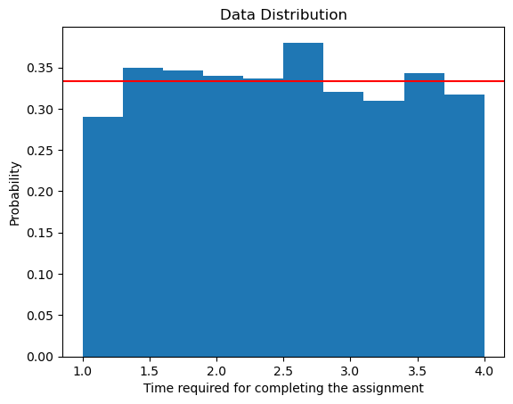

```python
# Visualize the distribution of the time needed for completing the assignment via histogram
plt.hist(assignment['Time_taken'], density = True)

plt.axhline(1 / 3, color = 'red')

plt.xlabel('Time required for completing the assignment')

plt.ylabel('Probability')

plt.title('Data Distribution')

plt.show()
```

**a) Find the probability that a randomly selected student requires at most 2.5 hours to complete the assignment.**

**CDF** of a random variable (X) is the probability that X will take the value less than or equal to x. Mathematically, it can be represented as:

> $F_X(x) = P(X\leq x)$

In our case, the random variable (X) is the number of hours.

$ P(X\leq 2.5)$

```python
uniform.cdf(x = 2.5, loc = 1, scale = 3)
```

```
0.5
```

**b) Find the probability that a randomly selected student requires at least 3 hours to complete the quiz.**

$ P(X >= 3)$

```python
round(1 - uniform.cdf(x = 3, loc = 1, scale = 3), 4)
```

```
0.3333
```

**c) Find the probability that a randomly selected student requires 1.5 to 3.5 hours to complete the quiz.**

$ P(1.5 <= X <= 3.5)$

```python
round(uniform.cdf(x = 3.5, loc = 1, scale = 3) - uniform.cdf(x = 1.5, loc = 1, scale = 3), 4)
```

```
0.6667
```

## **Normal Distribution**

### **Q5. According to the Telecommunication Industry, the average monthly cell phone bill is Rs. 850, with a standard deviation of Rs. 150. Assuming that the monthly bill follows a normal distribution, answer the following questions.**

**a) What is the probability that a randomly selected cell phone bill is more than Rs. 1200?**

```python
# Calculate the cumulative probability for less than 1200 and then subtract from 1

round(1 - stats.norm.cdf(1200, loc = 850, scale = 150), 4)
```

```
0.0098
```

**b) What is the probability that a randomly selected cell phone bill is between Rs. 750 and Rs. 1200?**

```python
round(stats.norm.cdf(1200, loc = 850, scale = 150) - stats.norm.cdf(750, loc = 850, scale = 150), 4)
```

```
0.7377
```

**c) What is the probability that a randomly selected cell phone bill is no more than Rs. 650?**

```python
round(stats.norm.cdf(650, loc = 850, scale = 150), 4)
```

```
0.0912
```

**d) What is the amount above which lies the top 15% of cell phone bills?**

**Hint:** Let the amount be $M$.

$P(X ≥ M) = 0.15$

$=> 1 – P(X < M) = 0.15$

$=> P(X < M) = 0.85$

```python
# Use the percent point function, ppf, to complete calculation

stats.norm.ppf(0.85, loc = 850, scale = 150)
```

```
1005.4650084240685
```

**e) What is the amount below which lies the bottom 25% of cell phone bills?**

```python
round(stats.norm.ppf(0.25, loc = 850, scale = 150), 4)
```

```
748.8265
```

### **Q6. The mean filling capacity for a Coke bottle is 500 ml with a standard deviation of 20 ml. Assume that it follows a normal distribution and answer the following questions.**

```python
# Initialize variables
mu = 500

sigma = 20
```

**a) What is the probability that the bottle filled less than 480 ml of Coke?**

```python
x1 = 480

z1 = (x1 - mu) / sigma

p = stats.norm.cdf(z1)

print (' %1.4f' % p)
```

```
 0.1587
```

**b) What is the probability that the bottle filled more than 520 ml of Coke?**

```python
x2 = 520

z2 = (x2 - mu) / sigma

p1 = 1 - stats.norm.cdf(z2)

print ('%1.4f' % p1)
```

```
0.1587
```

**c) What is the probability that the bottle filled between 470 ml to 525 ml of Coke?**

```python
x3 = 470

z3 = (x3 - mu) / sigma

x4 = 525

z4 = (x4 - mu) / sigma

p2 = stats.norm.cdf(z3)

p3 = stats.norm.cdf(z4)

p4 = p3 - p2

print ('%1.4f' %p4)
```

```
0.8275
```

### Q7: **In 2-liter soft drink bottles, the drink filled is normally distributed, with a mean of 2.0 liters and a standard deviation of 0.05 liter. If bottles contain less than 95% of the listed net content (1.90 liters), the manufacturer may be subject to a penalty by the state office of consumer affairs. Bottles that have a net quantity above 2.1 liters may cause excess spillage upon opening. Answer the following questions.**

```python
# Initialize variables
mu = 2

sigma = 0.05
```

**a) What is the probability that the bottle content is between 1.9 and 2.0 liters?**

```python
Prob = stats.norm.cdf(2, loc = mu, scale = sigma) - stats.norm.cdf(1.90, loc = mu, scale = sigma)

print('%3.4f' % Prob)
```

```
0.4772
```

**b) What is the probability that the bottle content is between 1.9 and 2.1 liters?**

```python
prob = stats.norm.cdf(2.1, loc = mu, scale = sigma) - stats.norm.cdf(1.9, loc = mu, scale = sigma)

print('%3.4f' % prob)
```

```
0.9545
```

**c) What is the probability that the bottle content is below 1.9 liters or above 2.1 liters?**

```python
prob1  =  stats.norm.cdf(1.9, loc = mu, scale = sigma)

prob2  =  1 - stats.norm.cdf(2.1, loc = mu, scale = sigma)

print('%3.4f' % (prob1 + prob2))
```

```
0.0455
```

**d) 99% of the bottles contain at least what amount of soft drink in them?**

```python
probability = stats.norm.ppf(0.01, loc = mu, scale = sigma)

print(round(probability, 2), "Liters")
```

```
1.88 Liters
```

## **Sampling Distribution**

### **Q8. Suppose an automobile battery manufacturer claims that the mean lifetime of their battery is 60 months with a standard deviation of 6 months. Suppose the distribution of battery life is approximately normal. Find the probability that the mean lifetime of 40 randomly sampled batteries will be less than 58 months.**

```python
# Import the required function
from scipy.stats import norm

# Declare and initialize the mean lifetime of battery as mu
mu = 60

# Declare and initialize the standard deviation of battery as sigma
sigma = 6

# Sample size
n = 40

# Find the sample standard deviation
s = sigma / np.sqrt(40)

# Find the probability
round(norm.cdf(58, loc = mu, scale = s), 4)
```

```
0.0175
```

## **Interval Estimation**

### **Q9. A random sample of 40 households was selected as part of a study on electricity usage, and the number of kilowatt-hours (kWh) was recorded for each household in the sample for the first quarter of 2022. The average usage was found to be 310 kWh. In a very large study in the first quarter of the previous year, it was found that the standard deviation of the usage was 89 kWh.**

### **Assuming the standard deviation is unchanged and that the usage is normally distributed, provide an expression for calculating the 95% confidence interval for the mean usage in the first quarter of 2022.**

```python
# Import the required function
from scipy.stats import norm

import numpy as np

# Set the values of sample mean and sigma
x_bar, sigma = 310, 89

# Set the value of sample size
n = 40

# Construct the confidence interval
np.round(norm.interval(0.95, loc = x_bar, scale = sigma / np.sqrt(n)), 2)
```

```
array([282.42, 337.58])
```

## **Hypothesis Testing**

### **Q10. You are the manager of a Chinese restaurant. You want to determine whether the waiting time to place an order has changed in the past month from its previous population mean value of 4.5 minutes. State the null and alternative hypothesis.**

Null hypothesi: The population mean has not changed from its previous value of 4.5 minutes. This is denoted as:

$H_0: µ = 4.5$

Alternative hypothesis: Opposite of the null hypothesis. The alternative hypothesis is that the population mean is not 4.5 minutes. This is denoted as:

$H_1: µ \neq 4.5$

### **Q11. Find the p-value of a two-tailed hypothesis test if the Z-stat = +2.00?**

```python
# Calculate the p-value for Z-stat = 2
p_val = 1 - stats.norm.cdf(2)

p_val

# Print result
print("The p_value is twice the p-value for the one-tailed test because this is a two-tailed test, %1.4f" %(p_val * 2))
```

```
The p_value is twice the p-value for the one-tailed test because this is a two-tailed test, 0.0455
```